# Singapore HDB Resale Flat Prices

- Introduction
- Data Exploration
- Exploratory Data Analysis
  - Analyses for 2010 - 2022
  - Choosing feature variables to predict HDB resale prices
- Predicting HDB apartment resale prices for the years of 2010 - 2022
  - Digging deeper into each feature variable
- Conclusions

## Introduction

As a millenial growing up in Singapore and starting out in my first job, one of my life’s goals is to own a house on this little red dot with my life partner (*read: wife*).

Here in Singapore, there are generally [two ways](https://www.propertyguru.com.sg/property-guides/the-different-types-of-housing-in-singapore-9916) to do this:

- [Public Housing](https://www.hdb.gov.sg/about-us/our-role/public-housing-a-singapore-icon)
  - Brand new Built-to-Order (BTO) Flats (or apartments)
  - Resale Flats
- Private Housing (e.g., condominiums, landed property, etc.)

Whilst BTOs tend to be the choice of most young Singaporean couples, my current and potential future situation may push my partner and I to look towards resale flats to meet our housing needs. As such, I set forth on this project that will focus on resale flats under the Housing & Development Board (HDB). I hope to uncover insights into the relationships between variables related to resale flat prices and whether the data can be fitted into a model that may give an idea of future prices.

This project therefore seeks to analyse the prices of Singapore’s HDB Resale Flats for the years of 1990 - 2022. Data was obtained from Kaggle, [(1)](https://www.kaggle.com/datasets/syrahmadi/resale-hdb-flat-prices-2000-2022) and [(2)](https://www.kaggle.com/datasets/chngyuanlongrandy/hdb-prices-with-closest-mrt-distance), which were sourced from GovTech’s open data portal, [data.gov.sg](https://data.gov.sg/dataset/resale-flat-prices).

## Data Exploration

First, we will examine the data to understand its structure and contents.

```
## # A tibble: 6 × 10
##   month   town     flat_…¹ block stree…² store…³ floor…⁴ flat_…⁵ lease…⁶ resal…⁷
##   <chr>   <chr>    <chr>   <chr> <chr>   <chr>     <dbl> <chr>     <dbl>   <dbl>
## 1 1990-01 ANG MO … 1 ROOM  309   ANG MO… 10 TO …      31 IMPROV…    1977    9000
## 2 1990-01 ANG MO … 1 ROOM  309   ANG MO… 04 TO …      31 IMPROV…    1977    6000
## 3 1990-01 ANG MO … 1 ROOM  309   ANG MO… 10 TO …      31 IMPROV…    1977    8000
## 4 1990-01 ANG MO … 1 ROOM  309   ANG MO… 07 TO …      31 IMPROV…    1977    6000
## 5 1990-01 ANG MO … 3 ROOM  216   ANG MO… 04 TO …      73 NEW GE…    1976   47200
## 6 1990-01 ANG MO … 3 ROOM  211   ANG MO… 01 TO …      67 NEW GE…    1977   46000
## # … with abbreviated variable names ¹flat_type, ²street_name, ³storey_range,
## #   ⁴floor_area_sqm, ⁵flat_model, ⁶lease_commence_date, ⁷resale_price

## # A tibble: 6 × 10
##   month   town     flat_…¹ block stree…² store…³ floor…⁴ flat_…⁵ lease…⁶ resal…⁷
##   <chr>   <chr>    <chr>   <chr> <chr>   <chr>     <dbl> <chr>     <dbl>   <dbl>
## 1 2000-01 ANG MO … 3 ROOM  170   ANG MO… 07 TO …      69 Improv…    1986  147000
## 2 2000-01 ANG MO … 3 ROOM  174   ANG MO… 04 TO …      61 Improv…    1986  144000
## 3 2000-01 ANG MO … 3 ROOM  216   ANG MO… 07 TO …      73 New Ge…    1976  159000
## 4 2000-01 ANG MO … 3 ROOM  215   ANG MO… 07 TO …      73 New Ge…    1976  167000
## 5 2000-01 ANG MO … 3 ROOM  218   ANG MO… 07 TO …      67 New Ge…    1976  163000
## 6 2000-01 ANG MO … 3 ROOM  320   ANG MO… 04 TO …      73 New Ge…    1977  157000
## # … with abbreviated variable names ¹flat_type, ²street_name, ³storey_range,
## #   ⁴floor_area_sqm, ⁵flat_model, ⁶lease_commence_date, ⁷resale_price

## # A tibble: 6 × 10
##   month   town     flat_…¹ block stree…² store…³ floor…⁴ flat_…⁵ lease…⁶ resal…⁷
##   <chr>   <chr>    <chr>   <chr> <chr>   <chr>     <dbl> <chr>     <dbl>   <dbl>
## 1 2012-03 ANG MO … 2 ROOM  172   ANG MO… 06 TO …      45 Improv…    1986  250000
## 2 2012-03 ANG MO … 2 ROOM  510   ANG MO… 01 TO …      44 Improv…    1980  265000
## 3 2012-03 ANG MO … 3 ROOM  610   ANG MO… 06 TO …      68 New Ge…    1980  315000
## 4 2012-03 ANG MO … 3 ROOM  474   ANG MO… 01 TO …      67 New Ge…    1984  320000
## 5 2012-03 ANG MO … 3 ROOM  604   ANG MO… 06 TO …      67 New Ge…    1980  321000
## 6 2012-03 ANG MO … 3 ROOM  154   ANG MO… 01 TO …      68 New Ge…    1981  321000
## # … with abbreviated variable names ¹flat_type, ²street_name, ³storey_range,
## #   ⁴floor_area_sqm, ⁵flat_model, ⁶lease_commence_date, ⁷resale_price

## # A tibble: 6 × 11
##   month   town     flat_…¹ block stree…² store…³ floor…⁴ flat_…⁵ lease…⁶ remai…⁷
##   <chr>   <chr>    <chr>   <chr> <chr>   <chr>     <dbl> <chr>     <dbl>   <dbl>
## 1 2015-01 ANG MO … 3 ROOM  174   ANG MO… 07 TO …      60 Improv…    1986      70
## 2 2015-01 ANG MO … 3 ROOM  541   ANG MO… 01 TO …      68 New Ge…    1981      65
## 3 2015-01 ANG MO … 3 ROOM  163   ANG MO… 01 TO …      69 New Ge…    1980      64
## 4 2015-01 ANG MO … 3 ROOM  446   ANG MO… 01 TO …      68 New Ge…    1979      63
## 5 2015-01 ANG MO … 3 ROOM  557   ANG MO… 07 TO …      68 New Ge…    1980      64
## 6 2015-01 ANG MO … 3 ROOM  603   ANG MO… 07 TO …      67 New Ge…    1980      64
## # … with 1 more variable: resale_price <dbl>, and abbreviated variable names
## #   ¹flat_type, ²street_name, ³storey_range, ⁴floor_area_sqm, ⁵flat_model,
## #   ⁶lease_commence_date, ⁷remaining_lease

## # A tibble: 6 × 11
##   month   town     flat_…¹ block stree…² store…³ floor…⁴ flat_…⁵ lease…⁶ remai…⁷
##   <chr>   <chr>    <chr>   <chr> <chr>   <chr>     <dbl> <chr>     <dbl> <chr>
## 1 2017-01 ANG MO … 2 ROOM  406   ANG MO… 10 TO …      44 Improv…    1979 61 yea…
## 2 2017-01 ANG MO … 3 ROOM  108   ANG MO… 01 TO …      67 New Ge…    1978 60 yea…
## 3 2017-01 ANG MO … 3 ROOM  602   ANG MO… 01 TO …      67 New Ge…    1980 62 yea…
## 4 2017-01 ANG MO … 3 ROOM  465   ANG MO… 04 TO …      68 New Ge…    1980 62 yea…
## 5 2017-01 ANG MO … 3 ROOM  601   ANG MO… 01 TO …      67 New Ge…    1980 62 yea…
## 6 2017-01 ANG MO … 3 ROOM  150   ANG MO… 01 TO …      68 New Ge…    1981 63 yea…
## # … with 1 more variable: resale_price <dbl>, and abbreviated variable names
## #   ¹flat_type, ²street_name, ³storey_range, ⁴floor_area_sqm, ⁵flat_model,
## #   ⁶lease_commence_date, ⁷remaining_lease
```

From these, we see that the data structure is generally similar. The only difference being that the “Jan 2015 - Dec 2016” and “Jan 2017 onwards” data consists of an extra column `remaining_lease`, indicating the remaining years of lease for the houses in the datasets. For the purpose of this project then, we will be dropping this column to maintain data uniformity.

Now that the data is similar, we can combine the datasets together. Looking into the dataset, we see that the `storey_range` variable has varied values, which we will be renaming into a new variable called `storeys`.

However, before we create the new variable, it would be helpful to understand the range of storey ranges among the resale flats and create a new variable to categorise them.

Even in 2022, very few resale flats have more than 12 to 15 floors, hence, everything above the 9th floor will be tagged as *“high”*.

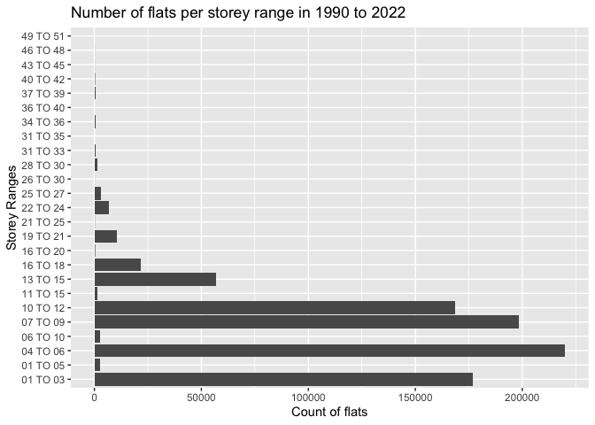

## Exploratory Data Analysis

Now that the data is cleaned, we can do some quick exploratory analyses.

First, we know that generally, HDB flat prices tend to vary by storey levels. We can visualise this layman assumption here:

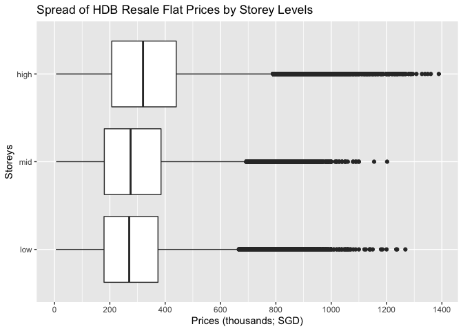

Although the variation and range of resale flat prices are relatively the same, the median prices for each of the storey categories seem to fit this assumption. That is, HDB flats on the lower levels generally tend to cost less than those on the higher levels.

One possible explanation for near similar variations and ranges could be the scope of the dataset, which covers approximately 30 years’ worth of data. Furthermore, the above chart does not take into account the HDB town, which, as most Singaporeans know, also influences the prices of flats.

Let’s examine the relationship between HDB towns and prices next:

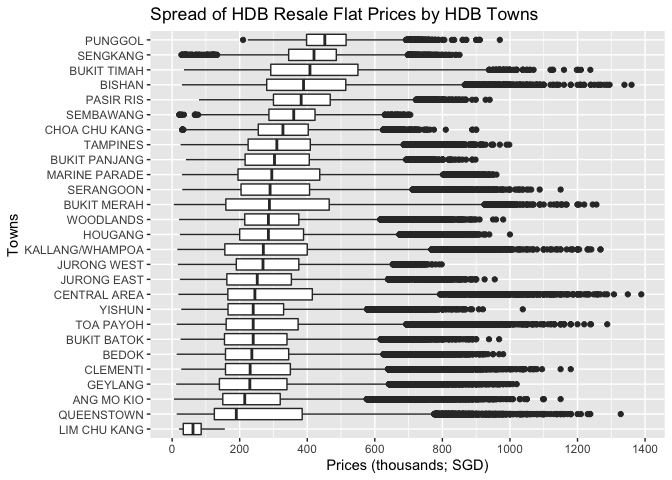

It is therefore evident that HDB resale flat prices do vary by their towns.

At this point, as mentioned above, the range of data is still massive with about 871,671 observations. For ease of and more focused analyses, we will narrow down the dataset by three conditions:

- Apartments from 2010 onwards (because we want newer houses and buildings)
- Apartments of at least 4-room and not multi-generation (so that we have a flat that is big enough to house at least 2 children)
- Apartments located on “mid” or “high” storeys (as we simply prefer being higher up and for the higher resale value over time)

```
## # A tibble: 6 × 13
##   month    year town       flat_…¹ flat_…² block stree…³ store…⁴ storeys floor…⁵
##   <chr>   <int> <chr>      <chr>   <fct>   <chr> <chr>   <chr>   <fct>     <dbl>
## 1 2010-01  2010 ANG MO KIO 4 ROOM  4-room  414   ANG MO… 07 TO … mid          92
## 2 2010-01  2010 ANG MO KIO 4 ROOM  4-room  472   ANG MO… 13 TO … high         92
## 3 2010-01  2010 ANG MO KIO 4 ROOM  4-room  624   ANG MO… 10 TO … high         93
## 4 2010-01  2010 ANG MO KIO 4 ROOM  4-room  643   ANG MO… 07 TO … mid         100
## 5 2010-01  2010 ANG MO KIO 5 ROOM  5-room  418   ANG MO… 07 TO … mid         148
## 6 2010-01  2010 ANG MO KIO 5 ROOM  5-room  545   ANG MO… 13 TO … high        118
## # … with 3 more variables: flat_model <chr>, lease_commence_date <dbl>,
## #   resale_price <dbl>, and abbreviated variable names ¹flat_type, ²flat_type2,
## #   ³street_name, ⁴storey_range, ⁵floor_area_sqm
```

This gives us a dataset with 38,695 observations - something much easier to work with and relatively more reflective of current trends, considering the recency of the data.

### Analyses for 2010 - 2022

Here, we repeat the analyses from the previous section using the filtered dataset.

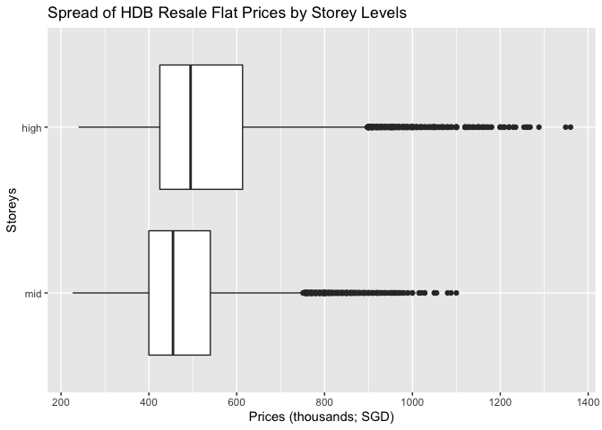

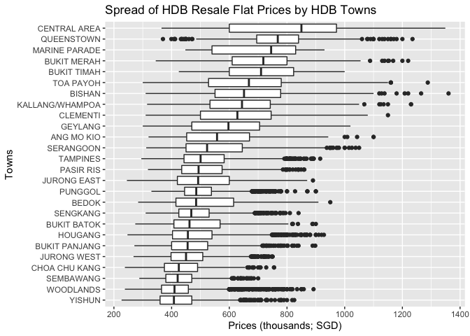

We also add another analysis:

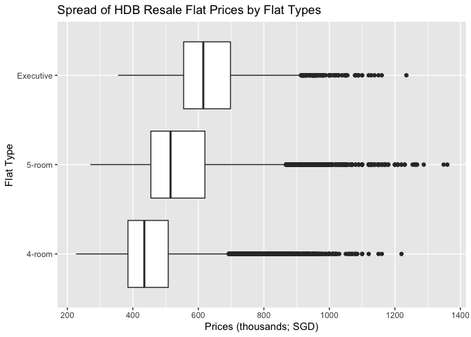

Another interesting observation is with the spread of resale prices by HDB towns.

Let’s take a look at both the unfiltered (left) and filtered (right) data visualisations side by side:

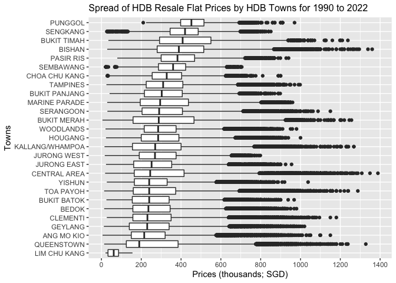

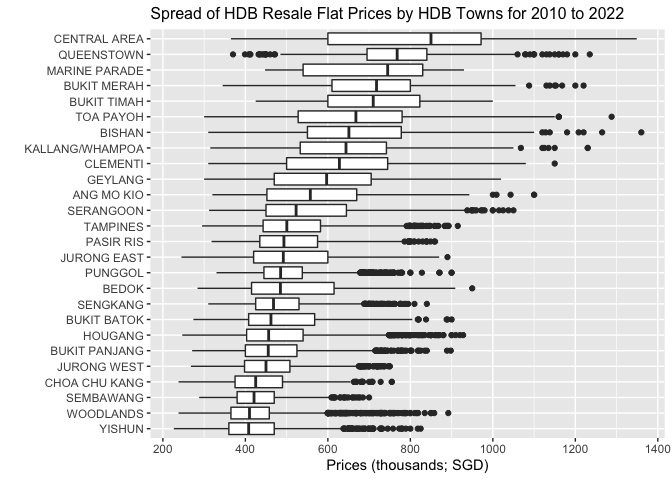

As Singapore developed further, with land scarcity increasing, more HDB flats needed to be built closer to the CBD to meet the demands of working professionals whose offices were located there. As such, even mature estates such as Queenstown and Bukit Merah, being some of the oldest estates in Singapore, with their newly developed HDB flats in the early 2000s, started seeing increased resale prices due to their proximity to the CBD. Furthermore, with the development of Sengkang and Punggol in line with more recent trends in HDB resale flat prices, these newer flats came out on top in terms of resale prices when being compared to flats that were built long before 2010, or even 2000.

This brings us to another variable that we have not investigated: the lease commencement date. The years variable used thus far were the years that the HDB flat was put on the resale market. As such, the lease commencement date would give an indicator of the age of the HDB flat.

Let’s take a look at the visualisation here:

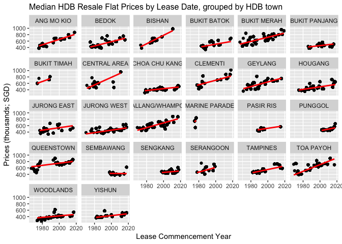

The plot above shows that there is a general upward trend for newer HDB flats, which by common logic, does make sense. The only “outlier” in this plot is that of HDB resale flats in Sembawang, which saw a downward trend followed by a spike in the late 2010s. This could have been due to recent urban developments in the Canberra area, located near Sembawang.

Nevertheless, when looking at the data as a whole, it still shows that the resale prices increased for newer HDB resale flats (rho = 0.251, *p* < 0,05).

```
##
##  Spearman's rank correlation rho
##
## data:  filtered_data$lease_commence_date and filtered_data$median_price_by_lease
## S = 7.2359e+12, p-value < 2.2e-16
## alternative hypothesis: true rho is not equal to 0
## sample estimates:
##       rho
## 0.2506549
```

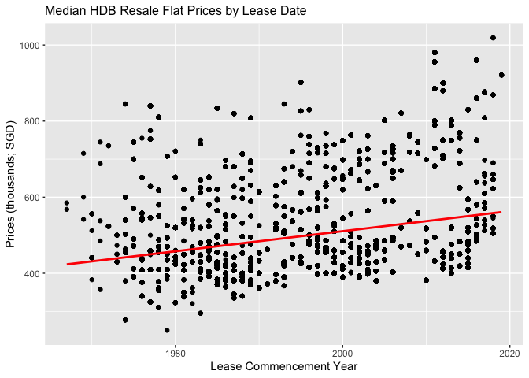

Finally, we can also examine whether the HDB resale prices follow a pattern or trend over time.

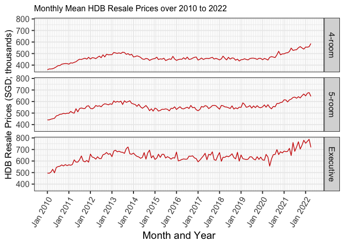

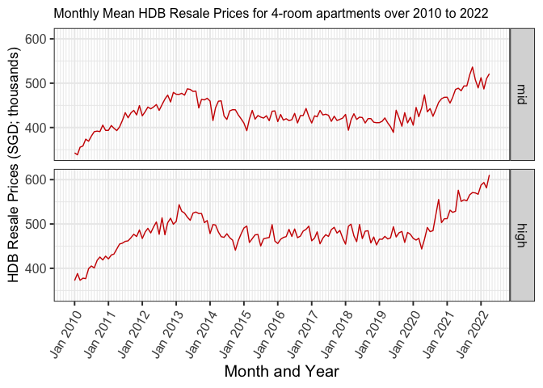

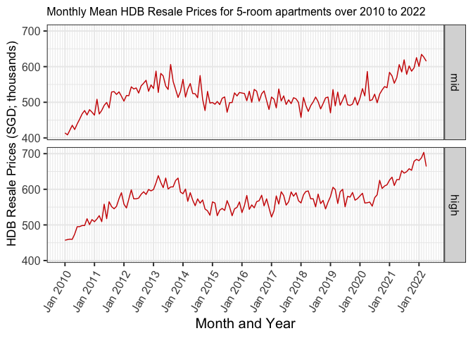

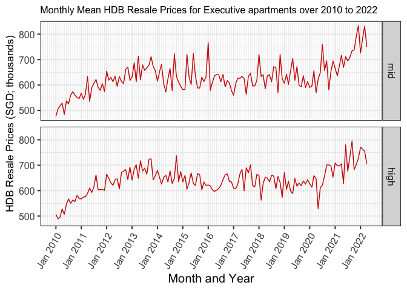

### Choosing feature variables to predict HDB resale prices

In predicting HDB resale prices, the exploratory analyses revealed some key variables:

- Flat-type (e.g., 4-room, 5-room, Executive)
  - This variable is synonymous with the floor area of the house, which is represented by the `floor_area_sqm` variable
- Month of sale
- Year of lease commencement (i.e., indicating the remaining length of the house lease at point of sale)
- Storeys (e.g., Mid or High floors)
- Region (i.e., indicated by Town, which indicates proximity to the CBD)

Out of these variables, we will need to create or calculate new variables for the length of housing lease at point of sale, for the housing region and for the month of sale.

For the town groupings by region, we will use the information found [here](https://en.wikipedia.org/wiki/Regions_of_Singapore).

As such, the feature variables we will be using to predict HDB resale prices would be:

- Flat Type (`flat_type2`)
- Floor area in sqm (`floor_area_sqm`)
- Remaining lease length in years (`remaining_lease_length`)
- Region (`region`)
- Floor level (`storeys`)
- Month of sale (`month_2`)

Since flat type and floor area are synonymous, we can conduct an ANOVA test on both variables to test for feature dependence and consider whether we should use both variables as features in a model or only one.

For this ANOVA test, we will set our alpha level to 0.1 and the null hypothesis that there is no difference between the means of the floor area for the flat types.

```
## Analysis of Variance Table
##
## Response: floor_area_sqm
##               Df  Sum Sq Mean Sq F value    Pr(>F)
## flat_type2     2 9370466 4685233   77207 < 2.2e-16 ***
## Residuals  38692 2347999      61
## ---
## Signif. codes:  0 '***' 0.001 '**' 0.01 '*' 0.05 '.' 0.1 ' ' 1
```

The ANOVA test showed that the p-value was less than 0.001 and so we can reject the null hypothesis; concluding that there is a mean difference between the floor area of flat types.

To determine which pairs of flat types had differences, we can conduct a series pairwise t-test with Bonferroni correction. We will set alpha to 0.1 for this test.

```
##
##  Pairwise comparisons using t tests with pooled SD
##
## data:  filtered_data$floor_area_sqm and filtered_data$flat_type2
##
##           4-room 5-room
## 5-room    <2e-16 -
## Executive <2e-16 <2e-16
##
## P value adjustment method: bonferroni
```

The pairwise t-tests showed p-values of less than 0.001 for all possible pairs, which means that we can reject all null hypotheses that there were no differences in mean floor areas between flat types. As such, we will be keeping both variables for predicting HDB resale prices.

## Predicting HDB apartment resale prices for the years of 2010 - 2022

After exploring our data and gaining some insights into the trends and factors possibly influencing resale prices, we will be modelling the prices to predict them.

For these linear regression models, the alpha level will be set at 0.1.

Three models were fitted:

1. A model with all the feature variables listed above (aka the Full model)
2. A model without the flat type variable
3. A model without the month of year variable

```
## MODEL INFO:
## Observations: 38695
## Dependent Variable: resale_price
## Type: Linear regression
##
## MODEL FIT:
## χ²(20) = 459128647515962.31, p = 0.00
## Pseudo-R² (Cragg-Uhler) = 0.59
## Pseudo-R² (McFadden) = 0.03
## AIC = 993973.99, BIC = 994162.39
##
## Standard errors: MLE
## --------------------------------------------------------------------
##                                      Est.      S.E.    t val.      p
## ---------------------------- ------------ --------- --------- ------
## (Intercept)                     192393.54   7991.52     24.07   0.00
## flat_type25-room                 42930.32   1748.21     24.56   0.00
## flat_type2Executive             101234.29   3442.75     29.41   0.00
## floor_area_sqm                    2092.59     63.74     32.83   0.00
## remaining_lease_length            3070.20     47.70     64.36   0.00
## regioneast                     -184964.82   1745.95   -105.94   0.00
## regionnorth                    -282939.00   1644.10   -172.09   0.00
## regionnorth-east               -212554.68   1495.88   -142.09   0.00
## regionwest                     -238367.42   1505.39   -158.34   0.00
## storeyshigh                      24983.04    991.06     25.21   0.00
## month_2February                   2499.78   2405.04      1.04   0.30
## month_2March                      1080.56   2241.75      0.48   0.63
## month_2April                      4411.63   2259.93      1.95   0.05
## month_2May                       -4450.62   2334.43     -1.91   0.06
## month_2June                      -5298.25   2289.35     -2.31   0.02
## month_2July                      -2286.79   2245.69     -1.02   0.31
## month_2August                     2523.11   2277.43      1.11   0.27
## month_2September                  6326.38   2312.60      2.74   0.01
## month_2October                    5928.02   2281.24      2.60   0.01
## month_2November                  10855.42   2328.24      4.66   0.00
## month_2December                  11675.33   2377.92      4.91   0.00
## --------------------------------------------------------------------
##
## Estimated dispersion parameter = 8378459300

```

[output cut: 51 more lines]

```
##                                      Est.      S.E.    t val.      p
## ---------------------------- ------------ --------- --------- ------
## (Intercept)                     194549.85   7857.41     24.76   0.00
## flat_type25-room                 42785.29   1750.30     24.44   0.00
## flat_type2Executive             100957.37   3446.99     29.29   0.00
## floor_area_sqm                    2097.08     63.82     32.86   0.00
## remaining_lease_length            3070.82     47.76     64.30   0.00
## regioneast                     -184876.16   1748.21   -105.75   0.00
## regionnorth                    -282901.15   1646.22   -171.85   0.00
## regionnorth-east               -212547.30   1497.84   -141.90   0.00
## regionwest                     -238487.06   1507.36   -158.21   0.00
## storeyshigh                      25033.09    992.24     25.23   0.00
## --------------------------------------------------------------------
##
## Estimated dispersion parameter = 8402177482
```

The r<sup>2</sup> values and the p-values for the coefficients of each model and for each full model were compared.

The results show that the full model was sufficient in explaining the HDB resale prices across 2010 and 2022, with r<sup>2</sup> = 0.586, *F* = 2740, *p* < 0.001. When certain variables were removed as in Models 2 and 3, the r<sup>2</sup> values would drop to 0.577 and 0.585 respectively, indicating a drop in the explainability of the model. The full model therefore showed a moderate variability (58.6%) in explaining HDB resale prices.

While dropping the month of year variable resulted in a change in r<sup>2</sup> of 0.001, the coefficients for the month of year variable had several values that had *p*-values less than 0.1 thereby still being able to explain the HDB resale prices.

#### Visualising simple effects

Examining the Full Model further, we will visualise the simple effects to ensure our insights above are validated based on the data.

```
## MODEL INFO:
## Observations: 38695
## Dependent Variable: resale_price
## Type: Linear regression
##
## MODEL FIT:
## χ²(20) = 459128647515962.31, p = 0.00
## Pseudo-R² (Cragg-Uhler) = 0.59
## Pseudo-R² (McFadden) = 0.03
## AIC = 993973.99, BIC = 994162.39
##
## Standard errors: MLE
## --------------------------------------------------------------------
##                                      Est.      S.E.    t val.      p
## ---------------------------- ------------ --------- --------- ------
## (Intercept)                     192393.54   7991.52     24.07   0.00
## flat_type25-room                 42930.32   1748.21     24.56   0.00
## flat_type2Executive             101234.29   3442.75     29.41   0.00
## floor_area_sqm                    2092.59     63.74     32.83   0.00
## remaining_lease_length            3070.20     47.70     64.36   0.00
## regioneast                     -184964.82   1745.95   -105.94   0.00
## regionnorth                    -282939.00   1644.10   -172.09   0.00
## regionnorth-east               -212554.68   1495.88   -142.09   0.00
## regionwest                     -238367.42   1505.39   -158.34   0.00
## storeyshigh                      24983.04    991.06     25.21   0.00
## month_2February                   2499.78   2405.04      1.04   0.30
## month_2March                      1080.56   2241.75      0.48   0.63
## month_2April                      4411.63   2259.93      1.95   0.05
## month_2May                       -4450.62   2334.43     -1.91   0.06
## month_2June                      -5298.25   2289.35     -2.31   0.02
## month_2July                      -2286.79   2245.69     -1.02   0.31
## month_2August                     2523.11   2277.43      1.11   0.27
## month_2September                  6326.38   2312.60      2.74   0.01
## month_2October                    5928.02   2281.24      2.60   0.01
## month_2November                  10855.42   2328.24      4.66   0.00
## month_2December                  11675.33   2377.92      4.91   0.00
## --------------------------------------------------------------------
##
## Estimated dispersion parameter = 8378459300
```

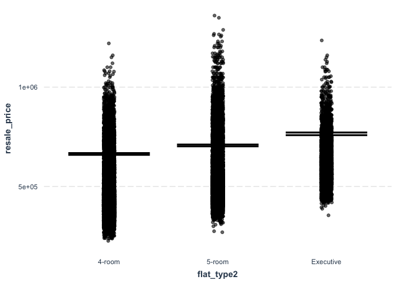

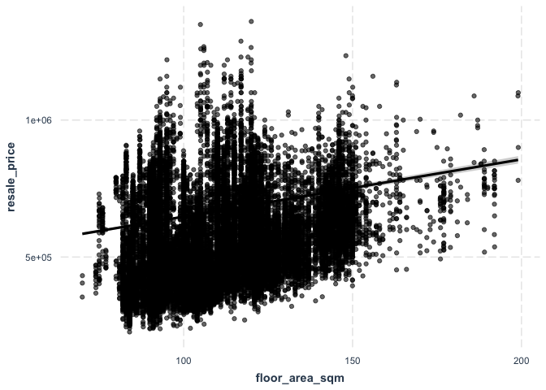

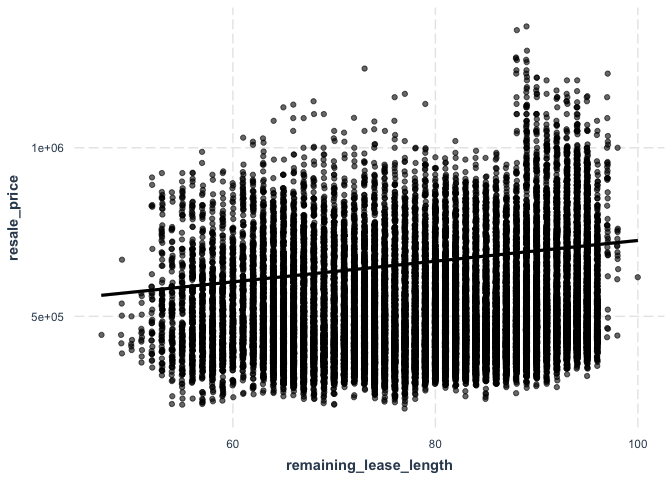

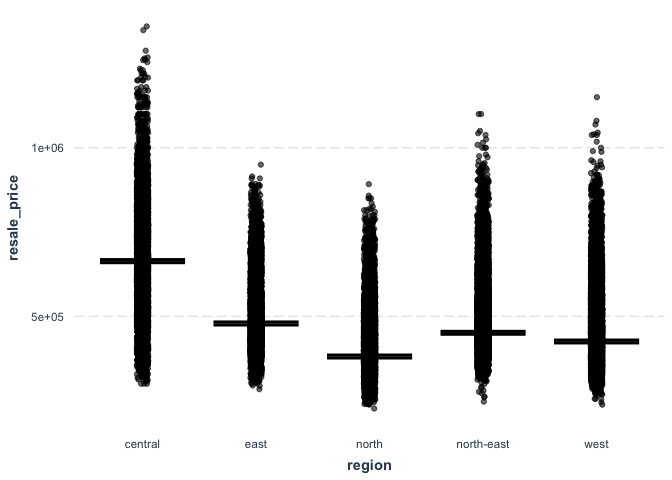

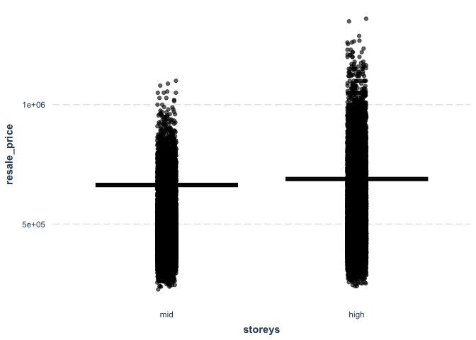

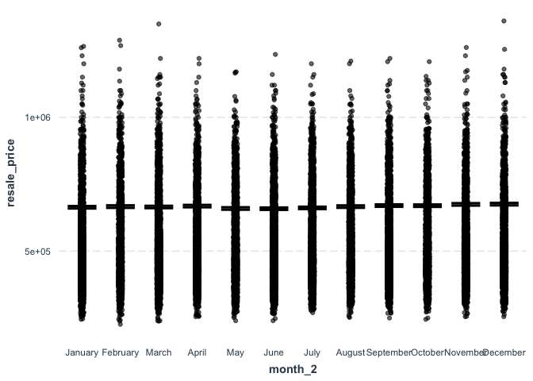

### Digging deeper into each feature variable

```
## MODEL INFO:
## Observations: 38695
## Dependent Variable: resale_price
## Type: Linear regression
##
## MODEL FIT:
## χ²(20) = 459128647515962.31, p = 0.00
## Pseudo-R² (Cragg-Uhler) = 0.59
## Pseudo-R² (McFadden) = 0.03
## AIC = 993973.99, BIC = 994162.39
##
## Standard errors: MLE
## --------------------------------------------------------------------
##                                      Est.      S.E.    t val.      p
## ---------------------------- ------------ --------- --------- ------
## (Intercept)                     192393.54   7991.52     24.07   0.00
## flat_type25-room                 42930.32   1748.21     24.56   0.00
## flat_type2Executive             101234.29   3442.75     29.41   0.00
## floor_area_sqm                    2092.59     63.74     32.83   0.00
## remaining_lease_length            3070.20     47.70     64.36   0.00
## regioneast                     -184964.82   1745.95   -105.94   0.00
## regionnorth                    -282939.00   1644.10   -172.09   0.00
## regionnorth-east               -212554.68   1495.88   -142.09   0.00
## regionwest                     -238367.42   1505.39   -158.34   0.00
## storeyshigh                      24983.04    991.06     25.21   0.00
## month_2February                   2499.78   2405.04      1.04   0.30
## month_2March                      1080.56   2241.75      0.48   0.63
## month_2April                      4411.63   2259.93      1.95   0.05
## month_2May                       -4450.62   2334.43     -1.91   0.06
## month_2June                      -5298.25   2289.35     -2.31   0.02
## month_2July                      -2286.79   2245.69     -1.02   0.31
## month_2August                     2523.11   2277.43      1.11   0.27
## month_2September                  6326.38   2312.60      2.74   0.01
## month_2October                    5928.02   2281.24      2.60   0.01
## month_2November                  10855.42   2328.24      4.66   0.00
## month_2December                  11675.33   2377.92      4.91   0.00
## --------------------------------------------------------------------
##
## Estimated dispersion parameter = 8378459300
```

Reviewing the linear regression coefficients, we see the following insights:

1. As predicted, as flat sizes increase, the resale prices would increase, all else being equal
2. As predicted, as remaining lease lengths increase, resale prices would increase, all else being equal
3. As predicted, for apartments on higher floors, resale prices would increase, all else being equal

Two feature variables deserve separate insights analyses:

- Region of apartment
  - All else being equal, compared to apartments in the Central region, apartments in the North, East, North-East and West regions would predict lower resale prices.
  - The order of resale prices by region from highest to lowest is as follows: Central > East > North-East > West > North
- Month of sale
  - As predicted, resale prices would decrease in the middle of the year (May to July), increase towards the end of the year, sustain at the beginning of the year and then fall again in mid-year.

At this point, some of the more obvious predictors would be flat sizes, remaining lease lengths and apartment floor level, where it is clear that the higher they go, the higher prices would go.

It seems that key variables that are would affect my decision-making would be the region of the HDB flat and the time of year that I purchase a flat. In sum, I can expect to pay on average, the lowest prices when purchasing flats in the North and aim to purchase one in May to June to take advantage of a fall in market prices.

This is what we see when visualising mean HDB resale prices by region across 2010 to 2022:

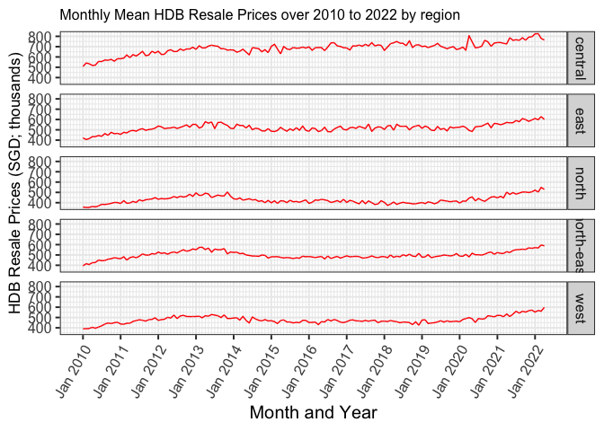

It is evident that resale prices are on a general upward trend, with the prices in the Central regions seeing the most volatility compared to other regions. More importantly, the prices in the North region are relatively the lowest, followed by both the West and North-East, then by East.

When visualising the month of year that a flat gets sold:

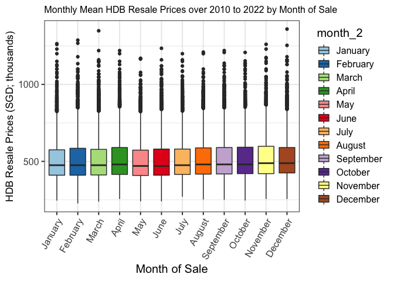

It is also evident that resale prices tend to be lowest in the mid-year months of May to June. As such, I could expect to find the lowest relative prices at this time of the year.

## Conclusions

I set out on this project with the aim of analysing HDB resale flat prices over time to uncover any insights or trends. As I had some layman intuition about the relationship between resale prices and several factors, the analyses here validated some of those assumptions and provided insight into other factors.

In short:

- Larger flat sizes, longer remaining lease lengths and units on higher floors command higher resale prices
- Different regions command different average prices, in order from highest to lowest: Central > East > North-East > West > North
- The time of the year when a unit is sold could determine its price relative to the market, with relatively lower prices consistently seen in May to June.

While there are many other factors affecting when a couple purchases a home (e.g., necessity and urgency of moving out), the variables analysed here were readily and publicly available and could serve to inform potential homeowners with the same criteria as me when studying HDB resale flat prices. With time in hand and adequate patience, one might be able to secure a flat when the market prices them at their lowest as compared to the rest of the year and also pick units in regions where prices are lower than others.

Thank you for looking through this humble project of mine. Please feel free to reach out to me for any feedback or enquiries through my social media or email as listed [here](https://github.com/iyliahutta).

The code for this project can be found in the .Rmd file of the repo or also [here as an R file](https://github.com/iyliahutta/singapore-hdb-resale-prices/blob/main/README.R).